[OHI British Columbia](http://www.ohibc.org/) | [OHI Science](http://ohi-science.org) | [Citation policy](https://github.com/OHI-Science/ohiprep/releases)

# OHIBC: CW trash layers prep

Compiled on Fri Apr 14 12:15:13 2017 by ohara

```r
knitr::opts_chunk$set(fig.width = 6, fig.height = 4, fig.path = 'Figs/',
                      echo = TRUE, message = FALSE, warning = FALSE)

library(rgdal)
library(raster)
source('~/github/ohibc/src/R/common.R')  ### an OHIBC specific version of common.R

dir_git     <- '~/github/ohibc'
dir_spatial <- file.path(dir_git, 'prep/spatial')  ### github: general buffer region shapefiles
dir_anx     <- file.path(dir_M, 'git-annex/bcprep')

### goal specific folders and info
goal     <- 'cw'
scenario <- 'v2017'
dir_goal <- file.path(dir_git, 'prep', goal, scenario)
dir_goal_anx <- file.path(dir_anx, goal, scenario)

### provenance tracking
library(provRmd); prov_setup()

### support scripts
source(file.path('~/github/ohibc/src/R/map_scores.R'))
  ### score plotting scripts
source(file.path(dir_git, 'src/R/rast_tools.R'))
  ### raster plotting and analyzing scripts

### set up the default BC projection to be BC Albers
p4s_bcalb <- c('bcalb' = '+init=epsg:3005')
```

# 1 Summary

This data is incorporated into the OHI British Columbia Clean Waters (CW) goal.

# 2 Data Source

**Reference**: [van Sebille et al, 2015](http://iopscience.iop.org/article/10.1088/1748-9326/10/12/124006/meta)

**Downloaded**: September 8, 2016 from Figshare: https://figshare.com/articles/data_of_microplastic_abundance_and_mass_from_Figure_3_of_Van_Sebille_et_al_2015_ERL_paper/1613256

**Native Data Resolution**: 1.0° in WGS84 projection

**Values**: Count (number/km2) and mass density (g/km2), based upon three different ocean circulation models (Lebreton, Maximenko, van Sebille)

**Time Range**: N/A

**Format**: CSV

# 3 Methods

## 3.1 Read in data

from: van Sebille et al 2015. A global inventory of small floating plastic debris. For this analysis we will use only the Van Sebille model for mass density rather than abundance.

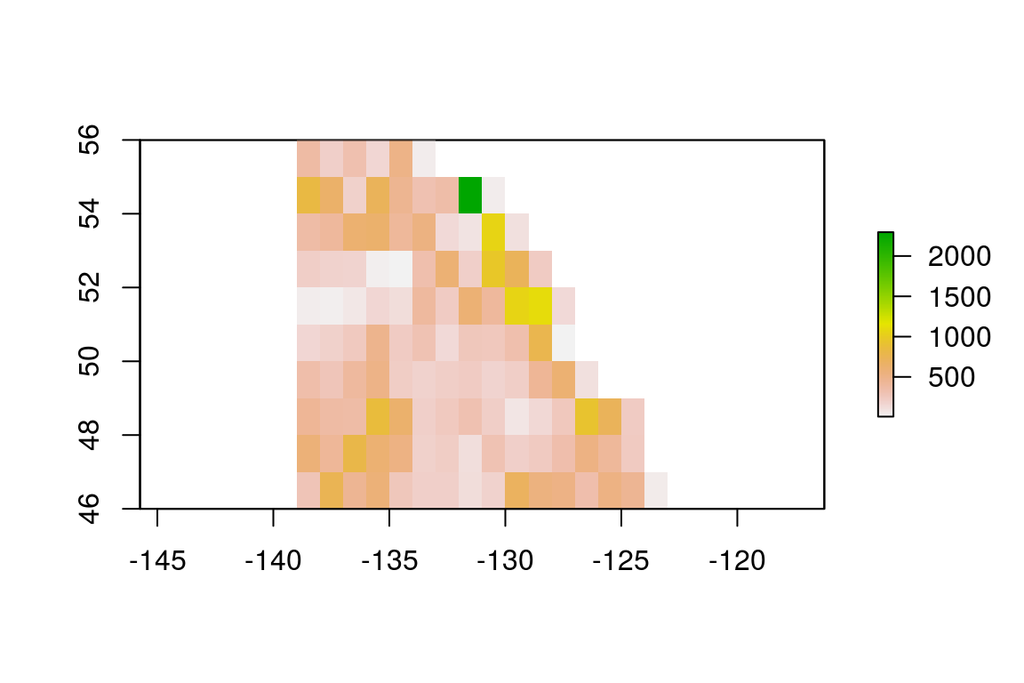

```r
dir_data_vs <- file.path(dir_M, 'git-annex/bcprep/_raw_data/vanSebille_plastics')

vs_files_all <- list.files(dir_data_vs, full.names = TRUE) %>%
  setNames(basename(.) %>% str_replace('.csv', ''))

# [1] "gridcell_areas"            "latitudes"                 "lebretonmodel_abundance"
# [4] "lebretonmodel_mass"        "longitudes"                "maximenkomodel_abundance"
# [7] "maximenkomodel_mass"       "vansebillemodel_abundance" "vansebillemodel_mass"

vs_files <- vs_files_all[str_detect(vs_files_all, 'vansebillemodel_mass')]
### select just Van Sebille mass layer for models

vs_rasts <- vector('list', length = length(vs_files)) %>%
  setNames(names(vs_files))

for (i in 1:length(vs_files)) { ### i = 1
  vs_file <- vs_files[i]
  vs_fn <- names(vs_files)[i]

  vs_matrix <- read_csv(vs_file, col_names = FALSE) %>%
    data.matrix() %>%
    .[2:181, 1:360]
    ### it appears that row 361 is glitchy; ditch it, and ditch +90 N row as well
  rownames(vs_matrix) <- c(90:-89)
  colnames(vs_matrix) <- c(0:359)

  vs_rast <- raster(vs_matrix)
  extent(vs_rast) <- c(0, 360, -90, 90)
  vs_rast <- rotate(vs_rast)
  crs(vs_rast) <- CRS('+init=epsg:4326')

  vs_rasts[[vs_fn]] <- vs_rast
}

vs_stack <- stack(vs_rasts)

### get BC raster at WGS84 projection to provide extents for cropping
bc_rgn_rast <- raster(file.path(dir_spatial, 'raster', 'ohibc_rgn_wgs84_30min.tif'))

bc_ext <- extent(bc_rgn_rast) %>% round()

vs_stack_crop <- crop(vs_stack, bc_ext)
plot(vs_stack_crop)
```

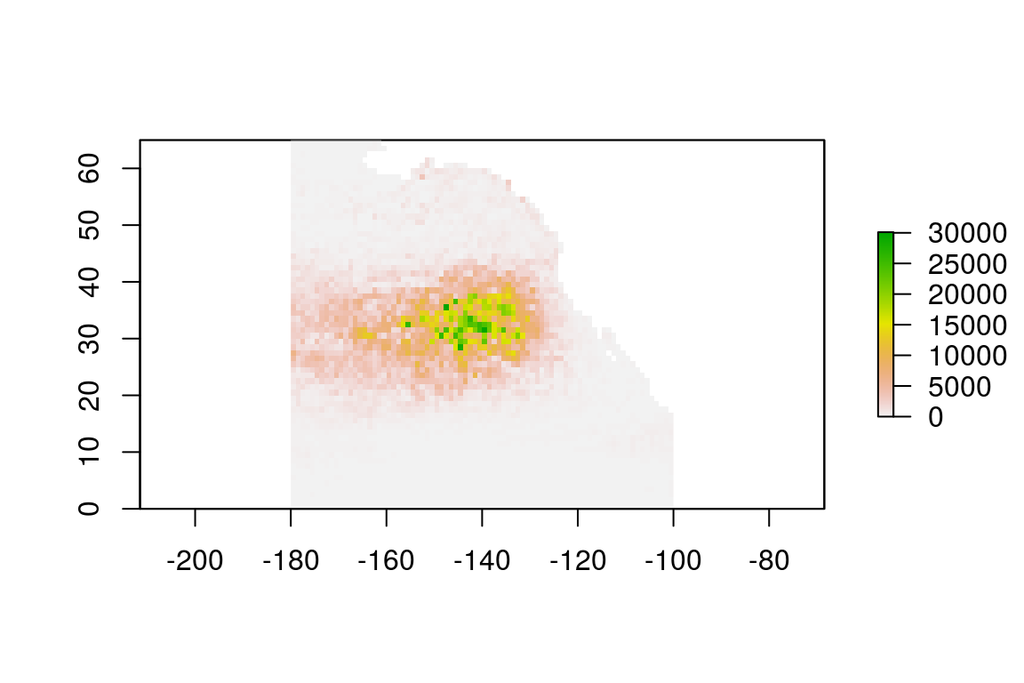

```r
### Save raster of van Sebille model by mass
writeRaster(vs_stack_crop[['vansebillemodel_mass']],
            file.path(dir_goal, 'int/cw_trash_mass_vansebille.tif'),
            overwrite = TRUE)

### create North East Pacific raster: north of Equator; west of 100 W and east of 100 E
n_pac_ext <- extent(c(-180, -100, 0, 65))
vs_mass_npac <- crop(vs_stack[['vansebillemodel_mass']], n_pac_ext)
plot(vs_mass_npac)
```

```r
### Save the global Van Sebille mass map cropped to the North Pacific for additional reference point options
writeRaster(vs_mass_npac,
            file.path(dir_goal, 'int/cw_trash_mass_vansebille_n_pac.tif'),
            overwrite = TRUE)
```

Crop to BC and interpolate using Thin Plate Spline to gapfill Strait of Georgia and coastal fjords.

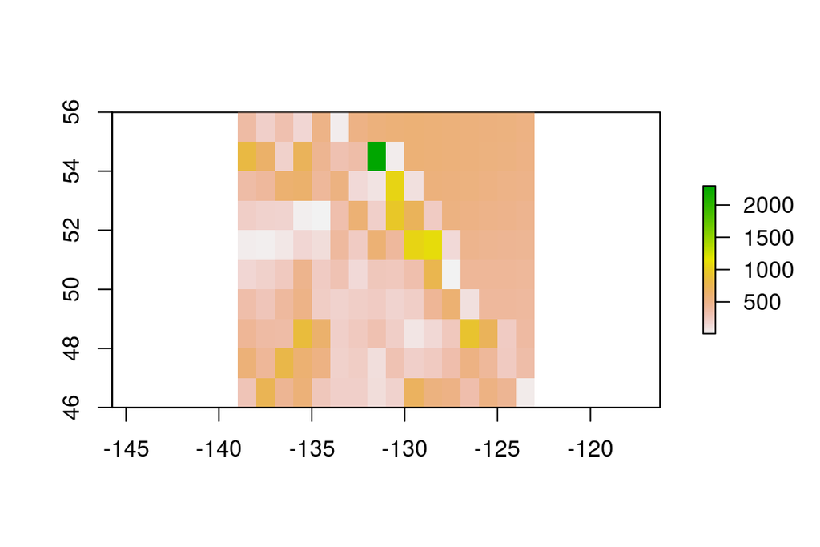

```r
trash_dens <- raster(file.path(dir_goal, 'int/cw_trash_mass_vansebille.tif'))

trash_dens_interp_file <- file.path(dir_goal, 'int/cw_trash_mass_interp.tif')

if(!file.exists(trash_dens_interp_file)) {
  message('Interpolating BC trash mass data')

  xy <- data.frame(xyFromCell(trash_dens, 1:ncell(trash_dens)))

  v  <- getValues(trash_dens)
  tmpdf <- cbind(xy, v) %>%
    filter(!is.na(v))
  xy1 <- tmpdf[ , 1:2]
  v1  <- tmpdf[ , 3]
  tps_model <- fields::Tps(xy1, v1)

  trash_dens_interp <- interpolate(trash_dens, tps_model)

  trash_dens_gapfilled <- trash_dens
  values(trash_dens_gapfilled)[is.na(values(trash_dens))] <- values(trash_dens_interp)[is.na(values(trash_dens))]

  message('Writing gapfilled BC trash mass to: ', trash_dens_interp_file)
  writeRaster(trash_dens_gapfilled, trash_dens_interp_file, overwrite = TRUE)

} else {
  message('Reading gapfilled BC trash mass from: ', trash_dens_interp_file)

  trash_dens_gapfilled <- raster(trash_dens_interp_file)
}

plot(trash_dens_gapfilled)
```

Reproject into BC Albers at 1000 m resolution

```r
rast_dens_interp <- raster(file.path(dir_goal, 'int/cw_trash_mass_interp.tif'))

### reproject to BC Albers
poly_eez_base <- readOGR(path.expand(dir_spatial), 'ohibc_rgn')
rast_base_bcalb <- raster(file.path(dir_spatial, 'raster/ohibc_rgn_raster_1000m.tif')) %>%
  crop(poly_eez_base)

trash_dens_bcalb <- projectRaster(from = rast_dens_interp, to = rast_base_bcalb, method = 'ngb')
values(trash_dens_bcalb)[is.na(values(rast_base_bcalb))] <- NA

writeRaster(trash_dens_bcalb, file.path(dir_goal, 'int/cw_trash_mass_bcalb.tif'), overwrite = TRUE)
```

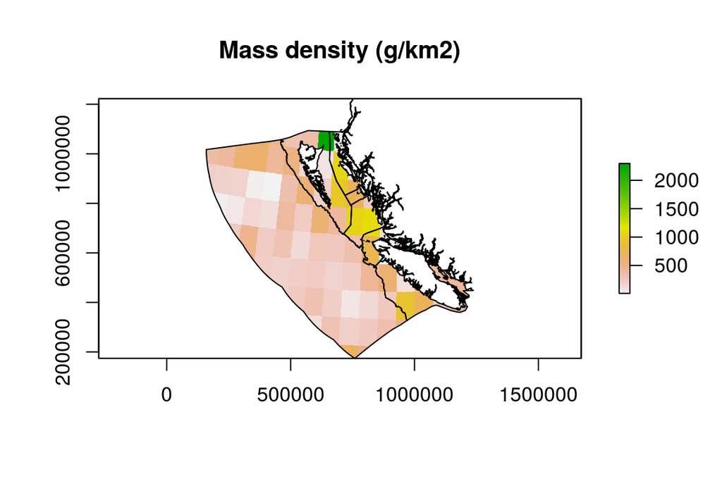

```r
plot(trash_dens_bcalb, main = 'Mass density (g/km2)')
plot(poly_eez_base, alpha = .5, add = TRUE)
```

## 3.2 Log Transform

Transform the values to a log(x + 1) value. Based on reference point discussions we will not do log transforms for this goal.